# Crimes Patrimoniais em MG

## **1. Introdução**

O objetivo deste trabalho é realizar uma análise da metodologia do artigo “Uma análise teórica e empírica sobre o comportamento dos crimes patrimoniais no estado de Minas Gerais no período de 2000 a 2015”. Será feita uma breve introdução do artigo focando nas metodologias adotadas e principais resultados obtidos.

O artigo analisou alguns dos fatores que podem ter influenciado a evolução do número de crimes violentos contra o patrimônio em Minas Gerais. Primeiro foi realizada uma revisão de literatura sobre a teórica econômica do crime e revisitar o modelo de oferta individual de crimes de Gary S. Becker (1968).

Após a revisão de literatura é feita uma análise dos dados sobre o comportamento dos crimes patrimoniais no estado mineiro utilizando a metodologia dos dados em painel. Foram utilizadas as seguintes variáveis no modelo:

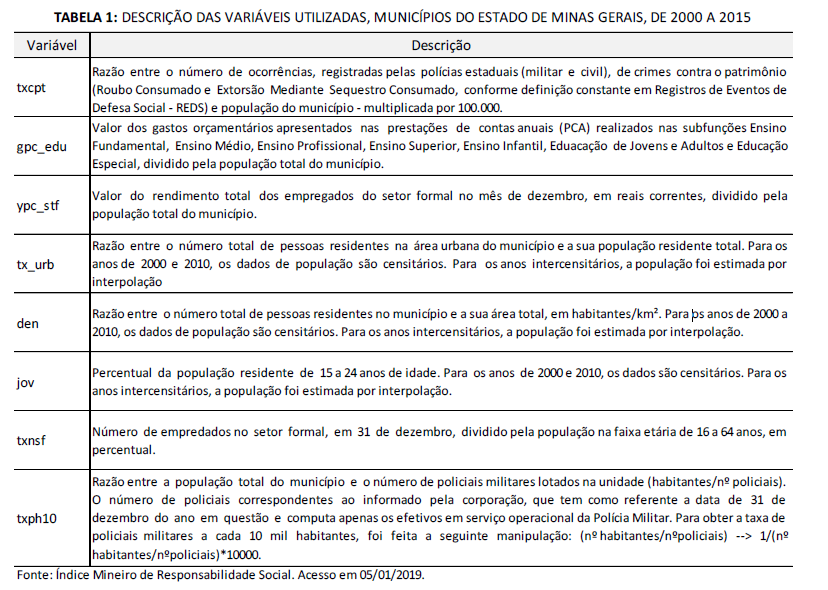

Variáveis do modelo

O modelo populacional a ser estimado é dado por:

$${txcpt}_{it}=\beta_0+\beta_1\ast{gpc_{edu}}_{it}+\beta_2\ast\ {ypc_{stf}}_{it}+\beta_3\ast{tx_{urb}}_{it}+\beta_4\ast{den}_{it\ }+\beta_5\ast jov+\beta_6\ast txnsf+\beta_7\ast txph10+{\ u}_{it}$$
Em que i é i-ésimo município no vetor de municípios mineiros na amostra e t é um determinado período de tempo no vetor da variável tempo. Assume-se que o termo de erro $u_{it}$ tem média e variância constantes ao longo do tempo e que não há auto correlação serial, isto, ele é independente ao longo dos períodos e que também não tem covariância com as variáveis explicativas.

Será feita a mesma análise metodológica utilizando as séries mais atuais, que vão até 2019. Houve uma única mudança nas variáveis que em jov, que será utilizada o número de jovens e não o percentual. Na base de dados original não este indicador e seria necessário cria-lo com base nas populações dos municípios da base.

As principais conclusões que os autores chegaram foi que houve um significativo aumento nos crimes em cidades pequenas e que a taxa de crimes violentos contra o patrimônio está negativamente relacionada com o gasto per capita na área da educação, mas indicadores demográficos e de renda como taxa de urbanização, densidade demográfica, percentual de jovens na população e renda per capita do setor formal estão positivamente relacionados com a taxa de crimes violentos contra o patrimônio. Conclui-se pela indicação de políticas públicas de incentivo à redução da criminalidade.

## **2. Metologia de Dados em Painel**

Segundo Wooldridge (2016), a grande vantagem da metodologia dos dados em painel é que permitem analisar melhor as variações que comumente não são observadas em corte transversal, ou dados longitudinais, e ainda podem minimizar o viés e apresentar maior grau de liberdade.

Com isto e com base em Wooldridge (2002), os modelos de dados em painel podem ser estáticos ou dinâmicos. Num modelo de painel estático, assume-se que as variáveis explicativas são independentes dos termos de perturbação. Já no que tem a ver com a questão da heterogeneidade, pode-se assumir que esta reside nos coeficientes de regressão (que podem variar no tempo ou de indivíduo para indivíduo) ou na estrutura dos termos de perturbação.

Com base no que foi exposto acima, a escolha de uma especificação de validade universal é impossível, restando-nos escolher aquela que, face aos dados em concreto e ao tipo de problema em causa, melhor se adeque. O modelo dinâmico não será abordado nesta pesquisa.

Os modelos estáticos de dados em painel podem ser divididos em três tipos de metodologia: modelo de dados empilhados (pooled), modelos de dados em painel em efeitos fixos ou fixed effects (FE) e modelo dados em painel em efeitos aleatórios ou random effects (RE) (Gujarati e Porter, 2011).

A especificação de cada modelo encontra-se abaixo:

1. *Pooled:* É a técnica de painel que desconsidera as dimensões de tempo e espaço, onde se empilham as observações e obtém-se a regressão. O principal problema é camuflar a heterogeneidade que possa existir entre as variáveis. Os coeficientes estimados na equação podem ser tendenciosos e inconsistentes (Gujarati e Porter, 2011).
2. Efeitos Fixos: Combinam-se todas as observações, deixando que cada unidade de corte transversal tenha sua própria variável dummy (intercepto). O termo “efeitos fixos” deve-se ao fato de que, embora o intercepto possa diferir entre os indivíduos, o intercepto de cada indivíduo não varia com o tempo (Gujarati e Porter, 2011).
3. Efeitos Aleatórios: Propõe diferentes termos de intercepto para cada observação, contudo, interceptos fixos ao longo do tempo. O intercepto(comum) representa o valor médio de todos os interceptos (de corte transversal) e o componente de erro $\varepsilon_i$ representa o desvio (aleatório) do intercepto individual desse valor médio. No entanto, de que $\varepsilon_i$ não é diretamente observável; ele é o que se conhece como uma variável não observável ou latente (Gujarati e Porter, 2011).

Segundo Wooldridge (2016), para montar um modelo de dados em painel são utilizadas duas variáveis globais: uma variável identificadora de cada município analisado (id) e a variável indicadora de tempo (que vai montar a série temporal para cada variável).

Como é um painel curto e cada município, e cada um deles é independente na amostra ao longo do tempo, espera-se que o modelo de efeitos fixos seja o mais adequado, pois segundo Gujarati e Porter (2011, p.603), a inferência estatística é condicional às unidades de corte transversal observadas na amostra. Isso é adequado se realmente as unidades individuais ou de corte transversal da amostra não sejam extrações aleatórias de uma amostra maior, como é o caso dos estados. Nesse caso, o modelo de efeitos fixos é adequado.

Porém serão realizados testes de especificação adequados para a seleção do modelo mais eficiente e consistente, como mostrado em Wooldridge (2002), Wooldridge (2016) e Gujarati e Porter (2011). Inicialmente será realizado o teste F de Chow, cuja hipótese nula é de que não há mudança estrutural, para o qual, se o valor de F calculado for menor que F tabelado não rejeitaremos a hipótese nula. O resultado deste teste apresenta qual o melhor modelo a ser utilizado para regressão, se o Pooled ou Efeitos Fixos.

Posteriormente será realizado o teste de Hausman, que é utilizado para testar se há simultaneidade, e qual o melhor efeito, se o Efeito Fixo ou Efeito Aleatório. Tem como hipótese nula que se não há simultaneidade, a correlação é igual a zero. Se o valor exceder o da tabela, utiliza-se o efeito fixo (Wooldridge, 2016).

Por fim será realizado o teste de multiplicador de Lagrange de Breusch e Pagan, que verifica a presença de efeitos aleatórios no modelo, a hipótese nula do teste é a de que não há presença de efeitos aleatórios (Wooldridge, 2002).

Inicialmente, por se tratar de um painel curto, também se considera a hipótese de que os efeitos aleatórios estão correlacionados com um ou mais regressores no modelo, por isso não se colocou o termo de erro composto. Esta hipótese será testada por meio do teste de Hausman (Gujarati e Porter, 2011).

## **3. Análise Descritiva**

### **3.1. Carregando Pacotes**

```r
# 1. Carregando os pacotes necessarios:
library(car) #pacote para testes do modelo de regressao
library(AER) #pacote para mais testes do modelos
library(psych) #pacote para estatisticas descritivas
library(dplyr) #pacote para organizacao e tratamento dos dados
library(tidyr) #pacote para organizacao e tratamento dos dados
library(DescTools) #pacote para correcao de outliers
library(normtest) #pacote para testes de normalidade
library(openxlsx) #leitura dos dados em excel
library(readxl) #leitura dos dados em Excel
library(stargazer) #tabelas das regressoes
library(Hmisc) #correlacoes e testes
library(plm) # dados em painel.
library(stats) # organizacao dos dados

options(scipen=999) # evita a transformação para notação científica
```

### **3.2. Baixando os Dados para a Análise**

```r
# 2. Mudando o diretorio:
# setwd("~/Mestrado/USP/Econometria/bases")

# 3. Baixando os dados:
base <- read_excel("C:/Users/mvmar/Documents/painel.xls")

# 3.1. Declarando o painel:
base <- pdata.frame(base, index = c("id", "year"))

# 3.2. Corrigindo os valores faltantes:
base <- na.omit(base)

# 3.3. Balanceando o painel:
base <- make.pbalanced(base, balance.type = "shared.individuals")

pdim(base)
```

```
Balanced Panel: n = 796, T = 20, N = 15920
```

### **3.3. Estatísticas Descritivas**

A amostra da pesquisa foi balanceada e obteve 796 municípios para o estado de MG para os anos de 2000 a 2019. Os estados foram selecionados com base na disponibilidade dos dados. Os municípios desbalanceados e valores faltantes foram retirados da amostra.

```
Primeiramente serão realizadas as estatísticas descritivas para verificar a características dos dados. Seguem abaixo as estatísticas descritivas das variáveis do modelo:
```

```r
# 4. Observando os tipos de variaveis:
# str(base)

# 5. Estatisticas descritivas das variaveis quantitativas nao binarias:
descritivas <- psych::describe(base[, 4:11],
                               quant = c(.25, .75))
descritivas
```

|  | vars | n | mean | sd | median | trimmed | mad | min | max | range | skew | kurtosis | se | Q0.25 | Q0.75 |
| --- | --- | --- | --- | --- | --- | --- | --- | --- | --- | --- | --- | --- | --- | --- | --- |
| txcpt | 1 | 15920 | 88.89 | 165.98 | 47.08 | 59.66 | 53.84 | 0.00 | 6439.17 | 6439.17 | 12.05 | 318.16 | 1.32 | 18.54 | 102.36 |
| gpc_edu | 2 | 15920 | 416.89 | 1232.67 | 347.79 | 367.96 | 244.47 | 0.00 | 140968.70 | 140968.70 | 97.94 | 10806.05 | 9.77 | 197.53 | 537.19 |
| ypc_stf | 3 | 15920 | 146.10 | 174.22 | 100.76 | 116.79 | 79.39 | 0.14 | 3821.10 | 3820.96 | 7.06 | 96.20 | 1.38 | 56.42 | 178.74 |
| tx_urb | 4 | 15920 | 67.89 | 19.23 | 70.34 | 68.88 | 21.30 | 11.80 | 102.33 | 90.53 | -0.40 | -0.65 | 0.15 | 54.27 | 83.17 |
| den | 5 | 15920 | 65.25 | 320.36 | 22.69 | 27.50 | 18.47 | 1.32 | 7607.03 | 7605.71 | 16.41 | 328.86 | 2.54 | 12.77 | 42.10 |
| jovens | 6 | 15920 | 3907.76 | 16697.09 | 1395.50 | 1873.27 | 1090.45 | 110.00 | 453864.00 | 453754.00 | 20.38 | 493.33 | 132.33 | 814.00 | 2939.00 |
| txnsf | 7 | 15920 | 18.81 | 11.51 | 16.60 | 17.45 | 9.49 | 0.10 | 146.80 | 146.70 | 2.41 | 13.38 | 0.09 | 10.80 | 24.20 |
| txph10 | 8 | 15920 | 824.92 | 498.78 | 711.65 | 757.33 | 360.96 | 0.00 | 18711.76 | 18711.76 | 4.56 | 109.15 | 3.95 | 497.46 | 1015.06 |

As estatísticas descritivas são importantes para avaliar a distribuição dos dados para uma modelagem mais assertiva para a regressão. Com exceção das da variável de taxa de urbanização, todas as demais apresentaram forte assimetria, curtose e variabilidade, pois tiveram um coeficiente de variação igual ou maior a 30%. Antes da análise de regressão serão realizados testes para a detecção de outliers nestas variáveis, pois a regressão, assim como a análise ANOVA, é um análise de variância e é sensível à presença de valores extremos (Hair et al., 2009). Problemas com dispersão, assimetria e curtose nos dados podem gerar alta variabilidade no modelo, o que não é desejável.

Seguem abaixo a correção dos outliers nas variáveis do modelo:

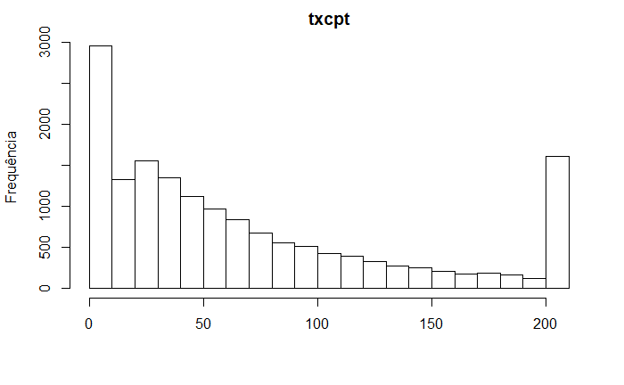

```r
# 6.3. Corrigindo os outliers na base:
base$txcpt <- Winsorize(base$txcpt, probs = c(.10, .90))
base$gpc_edu <- Winsorize(base$gpc_edu, probs = c(.05, .95))
base$ypc_stf <- Winsorize(base$ypc_stf, probs = c(.1, .90))
base$den <- Winsorize(base$den, probs = c(.10, .90))
base$jovens <- Winsorize(base$jovens, probs = c(.11, .89))
base$txnsf <- Winsorize(base$txnsf, probs = c(.05, .95))
base$txph10 <- Winsorize(base$txph10, probs = c(.05, .95))

# 6.4. Histograma e box-plot da variável dependente:
hist(base$txcpt, ylab = "Frequência", xlab = "",
     col = "white", main = "txcpt")
```

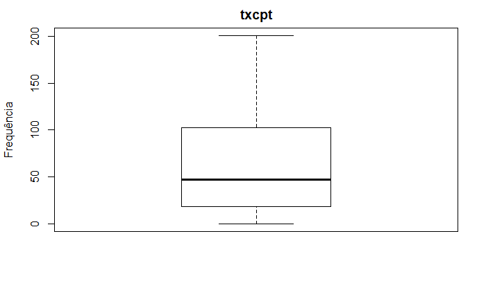

```r
boxplot(base$txcpt, ylab = "Frequência", xlab = "",
        col = "white", main = "txcpt")
```

### **3.4. Correlações Lineares**

Neste caso, espera-se uma forte correlação da variável com as demais variáveis e uma correlação fraca ou moderada entre as demais. Correlações lineares próximas de 1 ou -1 indicam que uma variável pode ser transformação linear de outra (Guimarães e Lima, 2008), gerando o problema da multicolinaridade no modelo (que será testada). Neste caso, quase todas as correlações entre as variáveis independentes foram baixas ou moderadas.

Seguem abaixo as correlações:

```r
# 10. Correlacoes. Como ha variaveis binarias no modelo, sera empregada a
# correlacao de Spearman, que e a mais indicada quando ha este tipo de variavel.
# A correlacao de Pearson funciona bem com dados quantitativos continuos e com
# baixa variabilidade.

correlates <- rcorr(as.matrix(base[, 4:11]),
                     type=c("pearson"))

correlacoes <- data.frame(correlates$r)


# Hide upper triangle
Data1 <- base[, c(4:11)]
Data.cor <- round(cor(Data1),3)
# Data.cor

upper<-Data.cor
upper[upper.tri(Data.cor)]<-""
upper<-as.data.frame(upper)
upper
```

|  | txcpt | gpc_edu | ypc_stf | tx_urb | den | jovens | txnsf | txph10 |
| --- | --- | --- | --- | --- | --- | --- | --- | --- |
| txcpt | 1 |  |  |  |  |  |  |  |
| gpc_edu | 0.116 | 1 |  |  |  |  |  |  |
| ypc_stf | 0.492 | 0.486 | 1 |  |  |  |  |  |
| tx_urb | 0.405 | 0.077 | 0.514 | 1 |  |  |  |  |
| den | 0.359 | -0.137 | 0.332 | 0.442 | 1 |  |  |  |
| jovens | 0.474 | -0.297 | 0.323 | 0.403 | 0.492 | 1 |  |  |
| txnsf | 0.441 | 0.236 | 0.853 | 0.539 | 0.353 | 0.345 | 1 |  |
| txph10 | 0.009 | -0.01 | 0.008 | -0.004 | -0.015 | -0.009 | 0.014 | 1 |

Vamos testar a significância estatísticas das correlações:

```r
# Algumas correlacoes foram acima de 0,95 e isto pode gerar multicolinearidade
# no modelo. Caso isto ocorra, algumas variaveis poderao ser retiradas.

# Signficancia das correalacoes:
correlacoes_p <- data.frame(correlates$P)
correlacoes_p
```

|  | txcpt | gpc_edu | ypc_stf | tx_urb | den | jovens | txnsf | txph10 |
| --- | --- | --- | --- | --- | --- | --- | --- | --- |
| txcpt | NA | 0.000000 | 0.0000000 | 0.0000000 | 0.00000000 | 0.0000000 | 0.00000000 | 0.26650821 |
| gpc_edu | 0.0000000 | NA | 0.0000000 | 0.0000000 | 0.00000000 | 0.0000000 | 0.00000000 | 0.20155503 |
| ypc_stf | 0.0000000 | 0.000000 | NA | 0.0000000 | 0.00000000 | 0.0000000 | 0.00000000 | 0.30153751 |
| tx_urb | 0.0000000 | 0.000000 | 0.0000000 | NA | 0.00000000 | 0.0000000 | 0.00000000 | 0.62296478 |
| den | 0.0000000 | 0.000000 | 0.0000000 | 0.0000000 | NA | 0.0000000 | 0.00000000 | 0.06624439 |
| jovens | 0.0000000 | 0.000000 | 0.0000000 | 0.0000000 | 0.00000000 | NA | 0.00000000 | 0.26511672 |
| txnsf | 0.0000000 | 0.000000 | 0.0000000 | 0.0000000 | 0.00000000 | 0.0000000 | NA | 0.08694486 |
| txph10 | 0.2665082 | 0.201555 | 0.3015375 | 0.6229648 | 0.06624439 | 0.2651167 | 0.08694486 | NA |

## **4. Modelo de Regressão**

### **4.1. Modelo Empilhado**

```r
# 11. Regressao por MQO: vamos avaliar o nosso modelo.
pooled <- plm(txcpt ~ log(gpc_edu) + log(ypc_stf) + tx_urb + den + jovens +
                      txnsf + txph10,
              data = base, model = "pooling")

summary(pooled)
```

```
Pooling Model

Call:
plm(formula = txcpt ~ log(gpc_edu) + log(ypc_stf) + tx_urb +
    den + jovens + txnsf + txph10, data = base, model = "pooling")

Balanced Panel: n = 796, T = 20, N = 15920

Residuals:
    Min.  1st Qu.   Median  3rd Qu.     Max.
-161.609  -36.086   -9.126   31.093  178.608

Coefficients:
                  Estimate    Std. Error  t-value              Pr(>|t|)
(Intercept)  -143.07234809    4.50905399 -31.7300 < 0.00000000000000022 ***
log(gpc_edu)    7.76609544    1.02292172   7.5921  0.000000000000033225 ***
log(ypc_stf)   24.97777925    1.51536328  16.4830 < 0.00000000000000022 ***
tx_urb          0.22039021    0.02775947   7.9393  0.000000000000002168 ***
den             0.22677993    0.02176540  10.4193 < 0.00000000000000022 ***
jovens          0.01265058    0.00030106  42.0205 < 0.00000000000000022 ***
txnsf           0.01773874    0.09344426   0.1898               0.84944
txph10          0.00199867    0.00101714   1.9650               0.04943 *
---
Signif. codes:  0 ‘***’ 0.001 ‘**’ 0.01 ‘*’ 0.05 ‘.’ 0.1 ‘ ’ 1

Total Sum of Squares:    65465000
Residual Sum of Squares: 41536000
R-Squared:      0.36553
Adj. R-Squared: 0.36525
F-statistic: 1309.59 on 7 and 15912 DF, p-value: < 0.000000000000000222
```

```r
vif(pooled)
```

```
log(gpc_edu) log(ypc_stf)       tx_urb          den       jovens        txnsf       txph10
    2.523135     7.102693     1.737563     1.486753     1.767899     4.414177     1.001041
```

```r
mean(vif(pooled))
```

```
[1] 2.861895
```

```r
# 8.3. Teste de especificação:
ramsey <- lm(txcpt ~ log(gpc_edu) + log(ypc_stf) + tx_urb + den + jovens +
                      txnsf + txph10,
              data = base)
reset(ramsey)
```

```
    RESET test

data:  ramsey
RESET = 55.197, df1 = 2, df2 = 15910, p-value < 0.00000000000000022
```

Agora vamos trabalhar com os modelos de efeitos fixos e efeitos aleatórios para fazer as comparações.

### **4.2. Modelo de Efeitos Fixos**

```r
# 8.4. Modelo de efeitos fixos:
fixos <-  plm(txcpt ~ log(gpc_edu) + log(ypc_stf) + tx_urb + den + jovens +
                      txnsf + txph10,
              data = base, model = "within")
summary(fixos)
```

```
Oneway (individual) effect Within Model

Call:
plm(formula = txcpt ~ log(gpc_edu) + log(ypc_stf) + tx_urb +
    den + jovens + txnsf + txph10, data = base, model = "within")

Balanced Panel: n = 796, T = 20, N = 15920

Residuals:
     Min.   1st Qu.    Median   3rd Qu.      Max.
-188.6617  -24.8403   -3.2803   21.1893  162.1918

Coefficients:
                Estimate  Std. Error t-value              Pr(>|t|)
log(gpc_edu)  8.14788357  1.11883126  7.2825    0.0000000000003439 ***
log(ypc_stf) 22.64029310  1.55694141 14.5415 < 0.00000000000000022 ***
tx_urb        0.12281938  0.04404925  2.7882              0.005306 **
den           2.19223648  0.21624119 10.1379 < 0.00000000000000022 ***
jovens       -0.00590253  0.00280766 -2.1023              0.035544 *
txnsf        -0.78432445  0.13096704 -5.9887    0.0000000021629684 ***
txph10       -0.00048433  0.00115111 -0.4207              0.673946
---
Signif. codes:  0 ‘***’ 0.001 ‘**’ 0.01 ‘*’ 0.05 ‘.’ 0.1 ‘ ’ 1

Total Sum of Squares:    27813000
Residual Sum of Squares: 23989000
R-Squared:      0.13746
Adj. R-Squared: 0.091702
F-statistic: 344.168 on 7 and 15117 DF, p-value: < 0.000000000000000222
```

### **4.3. Modelo de Efeitos Aleatórios**

```r
# 8.5. Modelo de efeitos aleatórios:
aleatorios <-  plm(txcpt ~ log(gpc_edu) + log(ypc_stf) + tx_urb + den + jovens +
                           txnsf + txph10,
                   data = base, model = "random")
summary(aleatorios)
```

```
Oneway (individual) effect Random Effect Model
   (Swamy-Arora's transformation)

Call:
plm(formula = txcpt ~ log(gpc_edu) + log(ypc_stf) + tx_urb +
    den + jovens + txnsf + txph10, data = base, model = "random")

Balanced Panel: n = 796, T = 20, N = 15920

Effects:
                  var std.dev share
idiosyncratic 1586.92   39.84 0.611
individual    1010.80   31.79 0.389
theta: 0.7302

Residuals:
     Min.   1st Qu.    Median   3rd Qu.      Max.
-179.3049  -27.2719   -5.3356   22.0704  156.5971

Coefficients:
                  Estimate    Std. Error  z-value              Pr(>|z|)
(Intercept)  -141.13300513    4.38916253 -32.1549 < 0.00000000000000022 ***
log(gpc_edu)    9.12747552    1.04008441   8.7757 < 0.00000000000000022 ***
log(ypc_stf)   25.25065721    1.47528375  17.1158 < 0.00000000000000022 ***
tx_urb          0.18408569    0.03899303   4.7210    0.0000023470064327 ***
den             0.42831936    0.05865491   7.3024    0.0000000000002828 ***
jovens          0.01222067    0.00075948  16.0908 < 0.00000000000000022 ***
txnsf          -0.64580654    0.11448249  -5.6411    0.0000000168972421 ***
txph10         -0.00014872    0.00111131  -0.1338                0.8935
---
Signif. codes:  0 ‘***’ 0.001 ‘**’ 0.01 ‘*’ 0.05 ‘.’ 0.1 ‘ ’ 1

Total Sum of Squares:    30553000
Residual Sum of Squares: 25449000
R-Squared:      0.16706
Adj. R-Squared: 0.16669
Chisq: 3191.44 on 7 DF, p-value: < 0.000000000000000222
```

### **4.4. Testes de Especificação para Escolha do Modelo**

```r
# 8.6. Teste de Chow: efeitos fixos x pooled
pFtest(fixos, pooled)
```

```
    F test for individual effects

data:  txcpt ~ log(gpc_edu) + log(ypc_stf) + tx_urb + den + jovens +  ...
F = 13.908, df1 = 795, df2 = 15117, p-value < 0.00000000000000022
alternative hypothesis: significant effects
```

```r
#F test for individual effects
#data:  crescimento ~ gini + educ_fem + invest_estad + pib_percapita
#F = 3.6877, df1 = 25, df2 = 359, p-value = 2.117e-08
#alternative hypothesis: significant effects

# 8.6. Teste LM de Breush-Pagan:
plmtest(pooled, type="bp")
```

```
    Lagrange Multiplier Test - (Breusch-Pagan) for balanced panels

data:  txcpt ~ log(gpc_edu) + log(ypc_stf) + tx_urb + den + jovens +  ...
chisq = 22298, df = 1, p-value < 0.00000000000000022
alternative hypothesis: significant effects
```

```r
#Lagrange Multiplier Test - (Breusch-Pagan) for unbalanced panels
#data:  crescimento ~ gini + educ_fem + invest_estad + pib_percapita
#chisq = 2.1467, df = 1, p-value = 0.1429
#alternative hypothesis: significant effects

# 8.7. Teste de Hausman:
phtest(fixos, aleatorios)
```

```
    Hausman Test

data:  txcpt ~ log(gpc_edu) + log(ypc_stf) + tx_urb + den + jovens +  ...
chisq = 136.95, df = 7, p-value < 0.00000000000000022
alternative hypothesis: one model is inconsistent
```

```r
#Hausman Test
#data:  crescimento ~ gini + educ_fem + invest_estad + pib_percapita
#chisq = 114.71, df = 4, p-value < 2.2e-16
#alternative hypothesis: one model is inconsistent
```

**Conclusão:** Pelos testes de especificação o modelo mais robusto foi o de Efeitos Fixos.

### **4.5. Testes de Eficiência do Modelo de Efeitos Fixos**

#### **4.5.1. Teste de Wooldridge para autocorrelação Serial de Dados em Painel**

```r
# 8.9. Teste de autocorrelação serial:
pbgtest(fixos)
```

```
    Breusch-Godfrey/Wooldridge test for serial correlation in panel models

data:  txcpt ~ log(gpc_edu) + log(ypc_stf) + tx_urb + den + jovens +  ...
chisq = 2536.7, df = 20, p-value < 0.00000000000000022
alternative hypothesis: serial correlation in idiosyncratic errors
```

A hipótese nula de não existência de autocorrelação serial nos resíduos foi rejeitada para o modelo de efeitos fixos. Neste caso, este problema deverá ser corrigido. Antes da correção será avaliada a dispersão nos resíduos.

#### **4.5.2. Teste de Breusch-Pagan para Heterocedasticidade em Grupo**

```r
# 8.9. Teste de autocorrelação serial:
bptest(fixos)
```

```
    studentized Breusch-Pagan test

data:  fixos
BP = 1240.1, df = 7, p-value < 0.00000000000000022
```

#### **4.5.3. Teste Jarque-Bera de Normalidade nos Resíduos* modelo de efeitos fixos**

```r
# 8.9. Teste de autocorrelação serial:
jb.norm.test(fixos$residuals)
```

```
    Jarque-Bera test for normality

data:  fixos$residuals
JB = 1012.6, p-value < 0.00000000000000022
```

O valor-p do teste Jarque-Bera foi de 0,00 rejeitando a hipótese nula de normalidade nos resíduos. Como o modelo de dados em painel cria uma série temporal para cada corte transversal a amostra ficou acima de 30 no painel, podendo dessa forma se trabalhar com a hipótese de normalidade assintótica.

```r
# 8.11. Erros-padrão robustos:
fixos_robust <- coeftest(fixos, vcov. = vcovHC)

stargazer(fixos, type = "text", ci = TRUE, title = "Resultados",
          dep.var.labels = "Crescimento", decimal.mark = ",")
```

```
Resultados
========================================
                 Dependent variable:
             ---------------------------
                     Crescimento
----------------------------------------
log(gpc_edu)          8,148***
                   (5,955, 10,341)

log(ypc_stf)          22,640***
                  (19,589, 25,692)

tx_urb                0,123***
                   (0,036, 0,209)

den                   2,192***
                   (1,768, 2,616)

jovens                -0,006**
                  (-0,011, -0,0004)

txnsf                 -0,784***
                  (-1,041, -0,528)

txph10                 -0,0005
                   (-0,003, 0,002)

----------------------------------------
Observations           15,920
R2                      0,137
Adjusted R2             0,092
F Statistic  344,168*** (df = 7; 15117)
========================================
Note:        *p<0,1; **p<0,05; ***p<0,01
```

## **5. Interpretação dos Resultados do Modelo**

Os gastos com ensino tiveram efeito positivo sobre o aumento esperado nas taxas de crimes contra o patrimônio, o que não faz sentido do ponto de vista econômico. O valor do rendimento total dos empregados do setor formal também teve efeito positivo, assim como tx_urb e den. Já o número de jovens e número de empregados no setor formal tiveram efeitos negativos. Já a razão entre a população total do município e o número de policiais militares lotados na unidade (habitantes/nº policiais) teve efeito nulo.

O modelo com dados em painel por efeitos fixos gerou resultados inadequados do ponto de vista teórico para este tipo de análise. Isto provavelmente ocorreu por conta da a alta correlação entre os crimes passados com os crimes no presente, o que parece ser mais adequado seria a estimação generalizada por momentos levando em consideração a variável dependente defasada.

## **Referências Bibliográficas**

GUJARATI, D. N.; PORTER, D. C. **Econometria básica**. 5. ed. Porto Alegre: AMGH, 2011. P. 588-603.

HAIR Jr., J.F.; BLACK, W.C.; BABIN, B.J.; ANDERSON, R.E. & TATHAM, R.L. **Análise multivariada de dados**. 6.ed. Porto Alegre, Bookman, 2009. 688p.

Hastings, Jr., Cecil; Mosteller, Frederick; Tukey, John W.; Winsor, Charles P. “Low moments for small samples: a comparative study of order statistics”. **Annals of Mathematical Statistics**, 1947.

Magalhães, MN; Lima, ACP. **Noções de Probabilidade e Estatística**. São Paulo. EDUSP, 2008.

WOOLDRIDGE, J. M. **Introdução à Econometria: uma abordagem moderna**. 3º ed. São Paulo: Cengage Learning, 2016.

WOOLDRIDGE, J., **Econometric analysis of cross section and panel data**, MIT Press, Cambridge, Massachusett, 2002.